# The impact of family smoking on adolescents

MiaMo

2019.07.15

source01:https://data.gov.tw/dataset/14475 (高中職生目前吸菸率)  
source02:https://data.gov.tw/dataset/14479 (高中職生家庭二手菸暴露率)

父母吸菸壞榜樣

根據《美國大學先驅報（universityherald）報導，校園禁菸的成功與否，要將家長的因素納入，幫家長戒菸或對家長曉以大義，請他們多關照小孩，如果自己無法戒也要清楚告訴小孩不可吸菸。

一項發表於《美國公共衛生期刊》的調查研究指出，父母親不吸菸的青少年中，有13%表示他們曾經吸過，而父母有吸菸的青少年中，有38%的曾經吸過菸。根據近期的研究，若青少年的父母親其中一人或兩人都吸菸，那這些青少年較可能吸菸並成癮。

本研究的主要作者丹尼斯（Denise Kandel）說：「大部份的吸菸者都是在青少年時期開始吸。如研究所顯示，父母的影響相當大，為了預防青少年開始吸菸成癮，我們必須更努力協助父母戒菸。」

```r
library(readxl)
family_smoking_rate <- read_excel("C:/Users/ASUS/Desktop/family_smoking_rate.xls")
student_smoking_rate <- read_excel("C:/Users/ASUS/Desktop/student_smoking_rate.xlt")
general=merge(family_smoking_rate,student_smoking_rate,by="year")
general
```

```
##   year TotalRateFamily 高中生家庭 TotalRateStudent 高中生
## 1 2005         48.8663    40.7262          15.2217 6.3701
## 2 2007         45.2580    32.6441          14.8142 3.6631
## 3 2009         41.6390    28.1981          14.7835 3.9786
## 4 2011         41.2391    26.4176          14.7474 3.5803
## 5 2012         39.5548    26.3636          14.1026 3.8638
## 6 2013         38.1250    27.7112          11.8762 2.9567
## 7 2014         31.9736    23.8068          11.5409 3.7168
## 8 2015         32.9564    21.0149          10.3535 2.3089
## 9 2016         32.3726    22.2460           9.2937 2.9411
```

# 利用ggplpt將資料視覺化後的分析

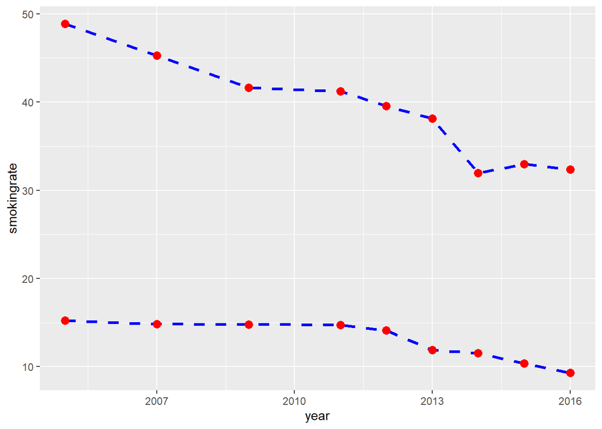

```r
library(ggplot2)
smokingrate <- read_excel("C:/Users/ASUS/Desktop/smokingrate.xls")
ggplot(data=smokingrate,aes(x=year,y=smokingrate,group=category))+
geom_line(linetype="dashed",color="blue",size=1.2)+
geom_point(color="red",size=3)
```

# 學生吸菸比長條圖

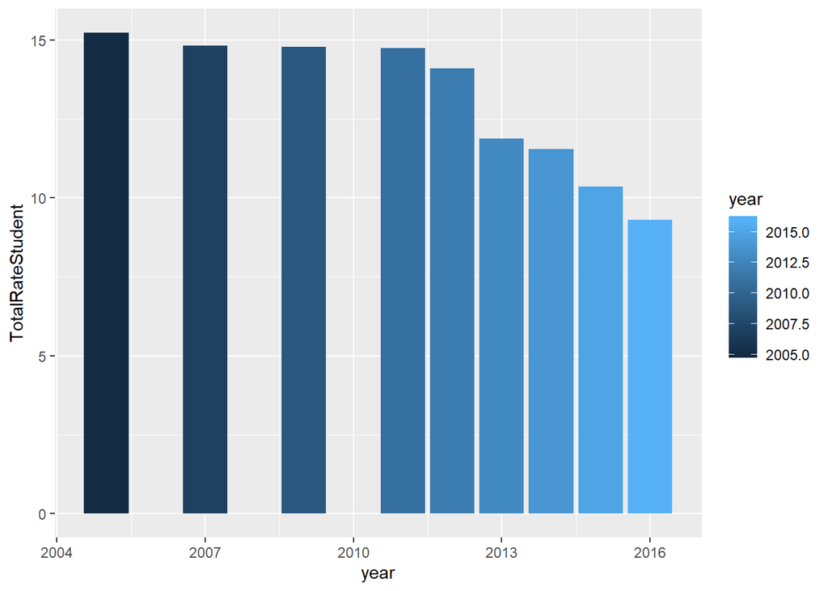

```r
ggplot(data=student_smoking_rate,aes(x=year,y=TotalRateStudent,fill=year))+geom_bar(stat="identity")
```

# 家庭吸菸比長條圖

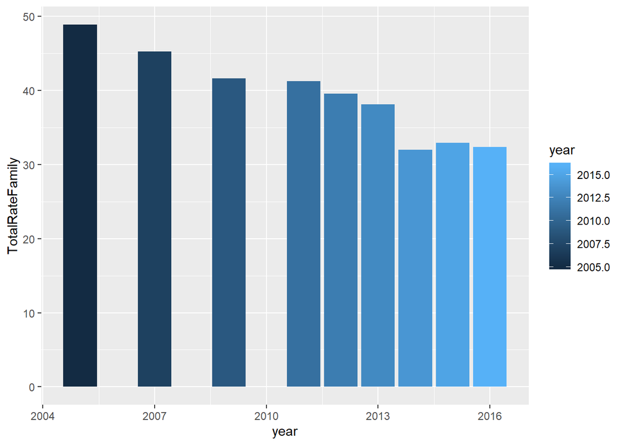

```r
ggplot(data=family_smoking_rate,aes(x=year,y=TotalRateFamily,fill=year))+geom_bar(stat="identity")
```

# 結論

除了國內的調查，國外研究也發現幾個導致青少年吸菸的因素  
家庭史(本次主要討論因素)：  
當家中有多位吸菸者時，青少年抽菸的頻率提高。家庭中，父母影響尤鉅；父母對抽菸的態度、觀感，親子關係都影響著青少年。父母失和、離婚、被家庭暴力傷害、亂倫、不成熟的父母、家庭連結薄弱都會增加風險。

陪伴者：  
朋友或家人抽菸頻率高的話，青少年很可能就會步上後塵。尤其剛轉入一個新的學校或團體時，容易取得香菸以及早年開始抽菸，都會增加危險性。

個人特質或精神病理問題：  
每個青少年都有其不同的價值系統、態度、所處環境、及個人知能（對學習及對社會）。具有反社會的、對學校反叛的、家庭關係或學業表現不佳的，很可能開始抽菸。有些青少年可能是為了要度過憂鬱或害怕而抽菸。

心理社會問題：  
青少年可能認為抽菸是種大人的表現，可能想模仿明星或運動員。女孩開始抽菸，也有可能是想要擺脫社會對女性的刻板印象。  
除了家庭以外還是有多因素會影響青少年吸菸的比率，但找到因素後再爭對每種因素去做防範，絕對是能更有效提升結果的!